# Part3_MachineLearning

```r
library(data.table)
library(dplyr)
library(caret)
library(RTextTools)
library(xgboost)
library(ROCR)
library(lime)
setwd("/home/usuario/Mis-datos") #Sustituir por el directorio donde se encuentren los datos
data <- read.csv("CleanData.csv", stringsAsFactors = FALSE)
head(data)
```

```
##      restaurante puntuacion review.id
## 1 Aboca Restobar          5         1
## 2 Aboca Restobar          4         2
## 3 Aboca Restobar          5         3
## 4 Aboca Restobar          5         4
## 5 Aboca Restobar          4         5
## 6 Aboca Restobar          5         6
##                                                                                                                                                                                                                                                                                                          …
## 1                                                                                                                                                                                                                                                                                                        …
## 2                                                                                                                                                                                                                                                                                                        …
## 3 Pizzeria artisan with charm cheap . The pizzas are delicious,you have great variety.From 9 euros you can have the pizzas handmade to your taste with 3 ingredients.They are all amazing.The children's menu up to 12 years does not reach € 7 and includes 1 pizza, 1 soda and 1 dessert which can be p…
## 4                                                                                                                                                                                                                                                      Great Pizzeria . One of my pizzas favorite is the …
## 5                                                                                                                                                                                                                                                                                                        …
## 6                                                                                                                                                      In a charming site . I wanted to thank all the staff at the restaurant, for making me feel at home, not only for the quality of the food, you noti…
##   longitud.comentario media.sentimiento mediana.sentimiento
```

[output cut: 20 more lines]

Vamos a crear una variabe vinaria para experesar las puntuaciones. Calificaremos como Buenos aquellos con 4 y 5 estrellas.

```r
set.seed(1234)
data$good.label <- 0
data$good.label[data$puntuacion == '4' | data$puntuacion == '5'] <- 1
head(data)
```

```
##      restaurante puntuacion review.id
## 1 Aboca Restobar          5         1
## 2 Aboca Restobar          4         2
## 3 Aboca Restobar          5         3
## 4 Aboca Restobar          5         4
## 5 Aboca Restobar          4         5
## 6 Aboca Restobar          5         6
##                                                                                                                                                                                                                                                                                                          …
## 1                                                                                                                                                                                                                                                                                                        …
## 2                                                                                                                                                                                                                                                                                                        …
## 3 Pizzeria artisan with charm cheap . The pizzas are delicious,you have great variety.From 9 euros you can have the pizzas handmade to your taste with 3 ingredients.They are all amazing.The children's menu up to 12 years does not reach € 7 and includes 1 pizza, 1 soda and 1 dessert which can be p…
## 4                                                                                                                                                                                                                                                      Great Pizzeria . One of my pizzas favorite is the …
## 5                                                                                                                                                                                                                                                                                                        …
## 6                                                                                                                                                      In a charming site . I wanted to thank all the staff at the restaurant, for making me feel at home, not only for the quality of the food, you noti…
##   longitud.comentario media.sentimiento mediana.sentimiento
```

[output cut: 20 more lines]

Particionamos los datos para train y test.

```r
trainIdx <- createDataPartition(data$good.label, p = .85, list = FALSE, times = 1)
train <- data[trainIdx, ]
test <- data[-trainIdx, ]
```

Como nuestro objetivo es ver la frecuencia de cada palabra, necesitaremos contar la aparición de cada una de ellas por comentario. Para ello crearemos una matriz donde los comenarios ocuparán las filas y las pablabas las columnas, y cada entrada de la matriz indicará en número de apariciones de cada palabara en cada comentario. Además para evitar tener en cuenta todas las palabras, solo nos quedaremos con aquellas palabras que aparezcan al menos un 1% (sparsity=1-0.1=0.99). Para conseguir quedarnos con las palabras que aparecen en los comentarios negativos, que son minoría, crearemos las matrices por separado y después las uniremos.

```r
sparsity <- .99
bad.dtm <- create_matrix(train$comentario.en[train$good.label == 0],
                         language = "english",
                         removeStopwords = FALSE,
                         removeNumbers = TRUE,
                         stemWords = FALSE,
                         removeSparseTerms = sparsity)

bad.dtm.df <- as.data.frame(as.matrix(bad.dtm),
                            row.names = train$review.id[train$good.label == 0])
```

```r
good.dtm <- create_matrix(train$comentario.en[train$good.label == 1],
                          language = "english",
                          removeStopwords = FALSE,
                          removeNumbers = TRUE,
                          stemWords = FALSE,
                          removeSparseTerms = sparsity)

good.dtm.df <- as.data.frame(as.matrix(good.dtm),
                          row.names = train$review.id[train$good.label == 1])
```

Unimos las dos matrices

```r
train.dtm.df <- bind_rows(bad.dtm.df, good.dtm.df)
train.dtm.df$review.id <- c(train$review.id[train$good.label == 0],
                            train$review.id[train$good.label == 1])
train.dtm.df <- arrange(train.dtm.df, review.id)
train.dtm.df$good.label <- train$good.label
```

```r
train.dtm.df <- train %>%
  select(-c(restaurante, comentario.en, puntuacion, good.label)) %>%
  inner_join(train.dtm.df, by = "review.id") %>%
  select(-review.id)

train.dtm.df[is.na(train.dtm.df)] <- 0
```

```r
test.dtm <- create_matrix(test$comentario.en,
                          language = "english",
                          removeStopwords = FALSE,
                          removeNumbers = TRUE,
                          stemWords = FALSE,
                          removeSparseTerms = sparsity)
test.dtm.df <- data.table(as.matrix(test.dtm))
test.dtm.df$review.id <- test$review.id
test.dtm.df$good.label <- test$good.label
```

```r
test.dtm.df <- test %>%
  select(-c(restaurante, comentario.en, puntuacion, good.label)) %>%
  inner_join(test.dtm.df, by = "review.id") %>%
  select(-review.id)
```

Ahora debemos asegurarnos de que nuestro test DTM tiene las mismas columnas que el de test:

```r
test.dtm.df <- head(bind_rows(test.dtm.df, train.dtm.df[1, ]), -1)
test.dtm.df <- test.dtm.df %>%
  select(one_of(colnames(train.dtm.df)))
test.dtm.df[is.na(test.dtm.df)] <- 0
```

Machine learning: Utilizaremos XGboost

```r
baseline.acc <- sum(test$good.label == "1") / nrow(test)

XGB.train <- as.matrix(select(train.dtm.df, -good.label),
                       dimnames = dimnames(train.dtm.df))
XGB.test <- as.matrix(select(test.dtm.df, -good.label),
                      dimnames=dimnames(test.dtm.df))
XGB.model <- xgboost(data = XGB.train,
                     label = train.dtm.df$good.label,
                     nrounds = 70,
                     objective = "binary:logistic")
XGB.predict <- predict(XGB.model, XGB.test)

XGB.results <- data.frame(good.label = test$good.label,
                          pred.label = XGB.predict)
```

Curva ROC

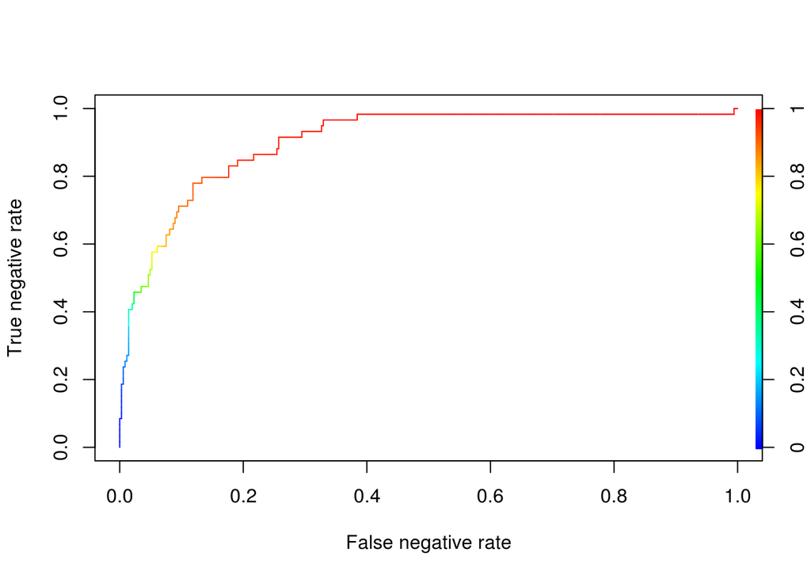

```r
ROCR.pred <- prediction(XGB.results$pred.label, XGB.results$good.label)
ROCR.perf <- performance(ROCR.pred, 'tnr','fnr')
plot(ROCR.perf, colorize = TRUE)
```

```r
XGB.table <- table(true = XGB.results$good.label,
                   pred = as.integer(XGB.results$pred.label >= 0.80))
XGB.table
```

```
##     pred
## true   0   1
##    0  35  24
##    1  24 322
```

```r
XGB.acc <- sum(diag(XGB.table)) / nrow(test)
```

Analisis de características

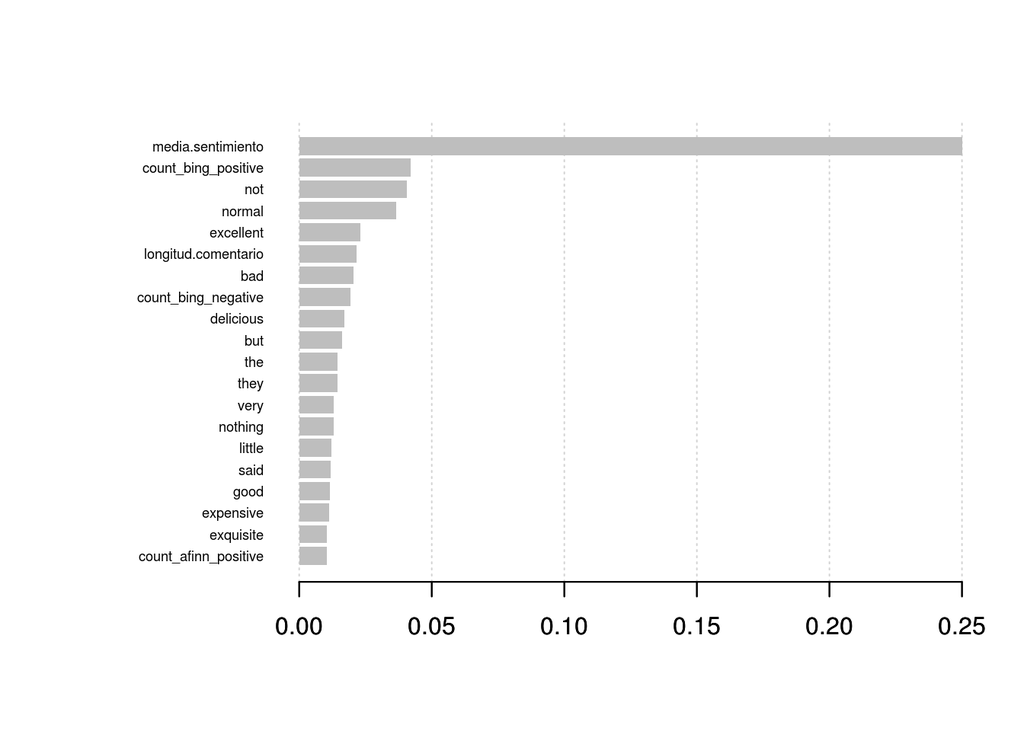

```r
names <- colnames(test.dtm.df)
importance.matrix <- xgb.importance(names, model = XGB.model)
xgb.plot.importance(importance.matrix[1:20, ])
```

Vamos a tratar de entender cuales son las características más importantes para realizar las predicciones

```r
test_labels_cor <- test.dtm.df$good.label == 1
test_labels_cor <- test.dtm.df[test_labels_cor,]
test_labels_cor_2 <- as.matrix(select(test_labels_cor, -good.label))

test_labels_wrong <- test.dtm.df$good.label == 0
test_labels_wrong <- test.dtm.df[test_labels_wrong,]
test_labels_wrong_2 <- as.matrix(select(test_labels_wrong, -good.label))
```

Para los comentarios negativos

```r
x_lime_n <- as.data.frame(XGB.train)
explainer_n <- lime(x_lime_n, model = XGB.model)

x_explain_n <- as.data.table(test_labels_wrong_2[2:3,])
explanation_n <- explain(x_explain_n, explainer_n, n_labels = 1, n_features = 20)
explanation_n[, 2:9]
```

```
##    case label label_prob  model_r2 model_intercept model_prediction
## 1     1     1  0.9898676 0.0380219     0.009761888       0.03565793
## 2     1     1  0.9898676 0.0380219     0.009761888       0.03565793
## 3     1     1  0.9898676 0.0380219     0.009761888       0.03565793
## 4     1     1  0.9898676 0.0380219     0.009761888       0.03565793
## 5     1     1  0.9898676 0.0380219     0.009761888       0.03565793
## 6     1     1  0.9898676 0.0380219     0.009761888       0.03565793
## 7     1     1  0.9898676 0.0380219     0.009761888       0.03565793
## 8     1     1  0.9898676 0.0380219     0.009761888       0.03565793
## 9     1     1  0.9898676 0.0380219     0.009761888       0.03565793
## 10    1     1  0.9898676 0.0380219     0.009761888       0.03565793
## 11    1     1  0.9898676 0.0380219     0.009761888       0.03565793
## 12    1     1  0.9898676 0.0380219     0.009761888       0.03565793
## 13    1     1  0.9898676 0.0380219     0.009761888       0.03565793
## 14    1     1  0.9898676 0.0380219     0.009761888       0.03565793
```

[output cut: 67 more lines]

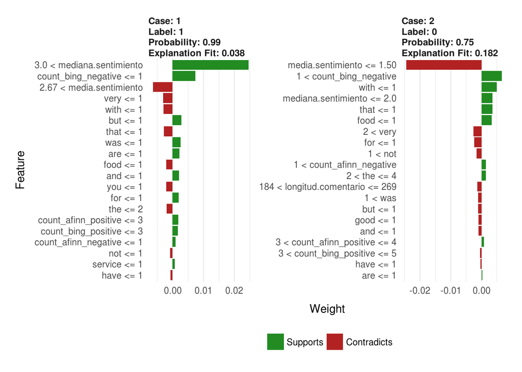

```r
plot_features(explanation_n)
```

Para los comentarios positivos

```r
x_lime_p <- as.data.frame(XGB.train)
explainer_p <- lime(x_lime_p, model = XGB.model)

x_explain_p <- as.data.table(test_labels_cor_2[1:2,])
explanation_p <- explain(x_explain_p, explainer_p, n_labels = 1, n_features = 20)
explanation_p[, 2:9]
```

[output not shown]

[output cut: 67 more lines]

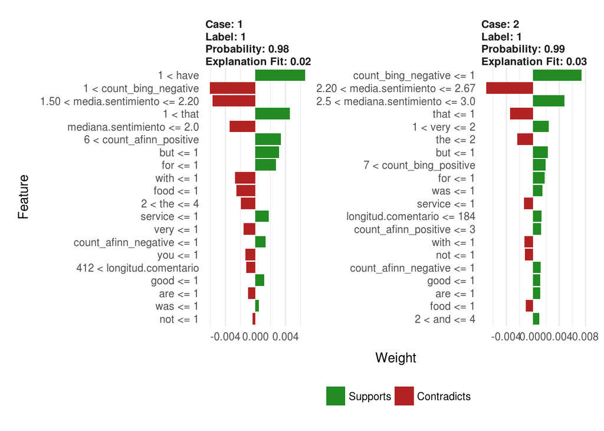

```r
plot_features(explanation_p)
```